# Unit 2 Programming basics作業總評

2021/10/20

> 總評初稿，傳送個人回饋單之後更新。

## 作業評分總原則

從這次的總評表開始，第一部分是總原則說明，讓同學了解教練與助教評分的方式。單元2開始有許多需要操作及理解的演練，根據不同主題，每個單元的演練項目數量與內容會有變化，請同學把握到單元8的上課互動演練項目，確認自已的設備與軟體設定足以應付需要操作的演練項目，理解統計觀念才能事半功倍。

### 準時推送(OT)

單元2起每次作業繳交期限是TA office hour結束後一小時。根據Assignment.html更新的日期時間決定，教練有寫R code，用來檢測各位同學的作業repo裡有沒有Assignment.html？Assignment.html的日期時間有沒有超過繳交期限？如果有作業網頁且未逾時，OT評分就是“非常厲害”；如果過了繳交期限，從單元3作業開始，OT評分就是“需要加把勁”，過了下一次上課開始時間，就沒有評分了。

單元2做為緩衝期，讓想上手但還未能掌握要領及需要解決軟體問題的同學跟上學習，週四上課前完成合格作業上傳，OT評分是“相當不錯”；單元3繳交期限前補繳，OT評分是“還算可以”，再逾期就都沒有評分囉。

### 演練充分度(OC)

為激勵同學使用Rmarkdown演練程式碼寫作及紀錄一般筆記，單元2開始會要求同學務必上傳有完整開頭的Assignment.html。因為單元2的上課內容尚未提到何謂有完整開頭的作業網頁，少數同學上傳的內容有誤，所以教練協助更正。請務必留意單元3上課說明，了解如何製作有完整開頭的Assignment.html。另一方面，繳交的作業缺少Assignment.html，就沒有OC評分了。

從單元2開始，大部分演練項目都會是在上課時完成，如果Assignment.html並沒有呈現這些項目的演練成果，但是有嘗試做課後演練項目，代表你上課時可能沒有跟上示範，課後並沒有嘗試加強學習，你的作業OC評分會是“需要加把勁”。

每個單元會有幾個項目是主要演練項目，主要演練項目的回答是用來評估你的OC評分是“還算可以”、“相當不錯”、還是“非常厲害”。如果每個演練項目你都有提出回答，但是主要演練項目的回答不夠完整，OC評分會你的整份作業答題狀況，得到“還算可以”或“相當不錯”，差異在於教練和助教都覺得你的主要演練項目可以改進的比例超過一半，就會是“還算可以”。如果所有演練項目都有做，主要演練項目有達到教練認可的標準，OC評分就是“非常厲害”。

### 演練活用度(EO)

EO評分以點數計算，計算方式目前有以下幾種：

- 回覆討論區的單元討論貼文

以下是出現在討論區，每個單元討論貼文的固定置頂內容。

```
歡迎分享你學習這個單元時發現的問題 (😄)
還有你認為有助學習這個單元的任何資訊或技巧 (🎉)
留意上課會出現意外的限量搶答(👍)

教練給予以上任何一種表情符號，均列入演練活用度評分。
```

由於表情符號是unicode字符的一種，教練能直接運用網頁搜尋計算次數，獲得任何一種表情符號，計一次EO點數。

- 分享運用心得

在討論區以“💡Ideas”張貼心得文，說明使用那些單元的技巧或觀念解決問題。

- 分享學習問題

在討論區以“🙏Q&A”張貼問題，說明你遇到的技巧或觀念問題。回覆者的回答有助解決問題，可獲得🎉 。

不論是那種狀況，一個單元每位同學可獲得的EO點數上限是4點。複數單元的心得或學習問題，請自行指定要計入那個單元作業評分。

## 單元2學習重點與建議

這個單元的練習1與練習5看似只要報告找到的資訊或執行結果，其實是引導同學習慣使用Rstudio做為自我學習統計的平台。例如練習1要同學找到關於`rnorm()`最精準的描述，在教練親自批改的作業裡，能找到精確描述的同學其實不多，以下引述範例提供同學互相學習：

- Random generation for the normal distribution with mean equal to mean and standard deviation equal to sd. (@alicee0426)
- rnorm.X : generates multivariate normal random variates in the space X. (@Hackerifyouwant)
- rnorm(n, mean = 0, sd = 1) rnorm generates random deviates. The length of the result is determined by n for rnorm, and is the maximum of the lengths of the numerical arguments for the other functions. (@Huang-Ya-Chi)

練習5有同學發現執行演練程式碼之後，物件資料會存在Environment。這是達到第一層的自學心得，如果你的自學心得達到第二層，應該會注意到inline code轉化到作業網頁的數值，都是來自存在Environment的物件。這次OC評分達到“相當不錯”或“非常厲害”，表示同學的自學心得至少達到第一層。

練習6的功能是引導同學建立引用資訊的正確觀念，這個單元是第一步，後續單元有許多演練項目展示在動態文件引用資訊的方法。雖然這次還沒有同學提出完整的做法，不過已經有人找到可用的套件：像是`citr`。

練習7是建立良好的程式寫作習慣演練的第一步。套件(package)在其他程式語言叫做函式庫(library)，是程式語言能發揮功能的關鍵。執行仼何動作前必要確認可以呼叫使用其中的函式，程式腳本或產品才能運作順暢。所以安裝套件是程式寫作工作之前的準備動作，並非工作過程應做的動作。

## 作業繳交狀況

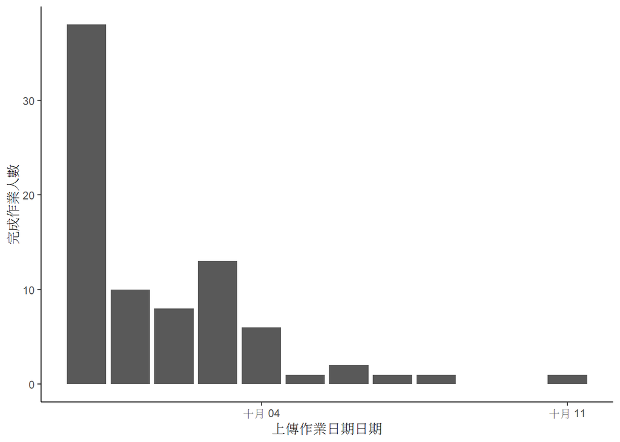

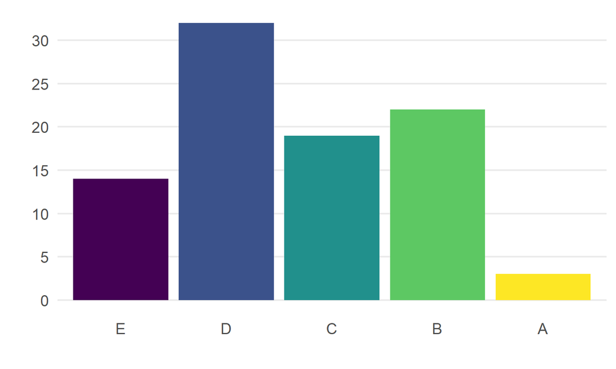

## 檢視個人回饋單

有收到個人評語的同學，只要將個人作業再拉回(git pull)個人的本機端Rstudio，以瀏覽器開啟feedback.html，就能看到教練和組教給的評語。